# Orthodont: solutions

Linear Mixed Models in Practice · PHTH 7440 · Northeastern University

Javier Álvarez Liébana

## The data

`nlme::Orthodont`: distance (mm) from the pituitary to the pterygomaxillary fissure in **27 children** (16 boys, 11 girls) at ages **8, 10, 12, 14** (Potthoff and Roy 1964).

```r
ortho <- as_tibble(nlme::Orthodont) |>
  mutate(Subject = factor(as.character(Subject)),  # unordered id
         age_c = age - 8)                          # 0 = first visit
ortho
```

```
#> # A tibble: 108 × 5
#>    distance   age Subject Sex   age_c
#>       <dbl> <dbl> <fct>   <fct> <dbl>
#>  1     26       8 M01     Male      0
#>  2     25      10 M01     Male      2
#>  3     29      12 M01     Male      4
#>  4     31      14 M01     Male      6
#>  5     21.5     8 M02     Male      0
#>  6     22.5    10 M02     Male      2
#>  7     23      12 M02     Male      4
#>  8     26.5    14 M02     Male      6
#>  9     23       8 M03     Male      0
#> 10     22.5    10 M03     Male      2
#> # ℹ 98 more rows
```

Part A · Look first

A

## Questions 1–3

Design, individual curves, mean profiles.

## 1. How many children, how many measurements?

```r
ortho |>
  summarise(children = n_distinct(Subject),
            measurements = n(), .by = Sex)
```

```
#> # A tibble: 2 × 3
#>   Sex    children measurements
#>   <fct>     <int>        <int>
#> 1 Male         16           64
#> 2 Female       11           44
```

```r
ortho |>
  count(Subject, name = "visits") |>
  count(visits, name = "children")
```

```
#> # A tibble: 1 × 2
#>   visits children
#>    <int>    <int>
#> 1      4       27
```

- **27 children**, **108 measurements**: every child has the **4 visits**.
- **Balanced** (same ages for everybody), **complete** (no drop-out), **equally spaced**.
- Opposite to `ChickWeight` (unbalanced, drop-out, 12 times).

## 2. Spaghetti plot: the random part

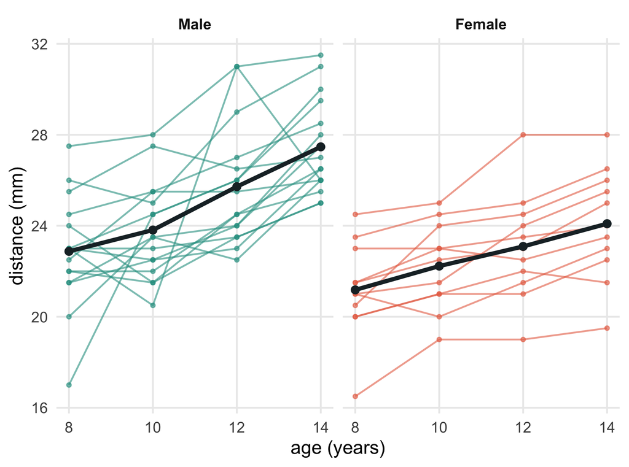

```r
ggplot(ortho, aes(age, distance, group = Subject, color = Sex)) +
  geom_line(alpha = .6) +
  geom_point(alpha = .6, size = 1.2) +
  stat_summary(aes(group = 1), fun = mean, geom = "line", color = "#1d2b30", linewidth = 1.6) +
  stat_summary(aes(group = 1), fun = mean, geom = "point", color = "#1d2b30", size = 2.5) +
  facet_wrap(~ Sex) +
  scale_color_manual(values = c(Male = "#2a9d8f", Female = "#e76f51"), guide = "none") +
  scale_x_continuous(breaks = c(8, 10, 12, 14)) +
  labs(x = "age (years)", y = "distance (mm)")
```

**What we see → what it implies**

- Each child **stays high or low** across visits (rarely cross) → measurements of a child are **correlated (not independent)**: a mixed model, not `lm()`.
- Children **start at very different intercepts** (≈ 17–28 mm at age 8), even within a sex → maybe each child its own level (random intercept): `(1 | Subject)`.
- Within a sex, lines are **roughly parallel** → maybe each child does not need its own rate (no random slope). The spread **does not fan out** with age → if children differ in rate, not by much.

The spaghetti plot is about **each child vs its group mean** (black line): it decides **ONLY the random part**.

## 3. Mean profiles: the fixed part

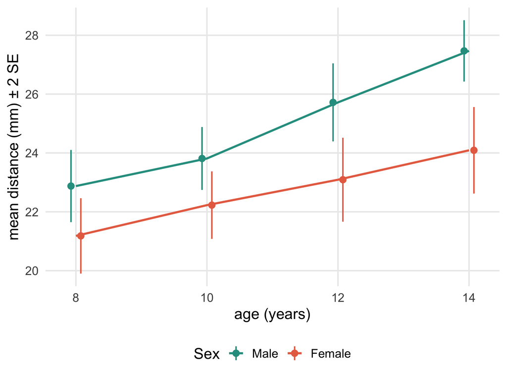

```r
prof <- ortho |>
  summarise(m = mean(distance), se = sd(distance) / sqrt(n()),
            .by = c(Sex, age))

ggplot(prof, aes(age, m, color = Sex)) +
  geom_line(linewidth = 1) +
  geom_pointrange(aes(ymin = m - 2 * se, ymax = m + 2 * se),
                  position = position_dodge(.3), size = .4) +
  scale_color_manual(values = c(Male = "#2a9d8f", Female = "#e76f51")) +
  scale_x_continuous(breaks = c(8, 10, 12, 14)) +
  labs(x = "age (years)", y = "mean distance (mm) ± 2 SE")
```

```r
prof |>
  select(Sex, age, m) |>
  pivot_wider(names_from = Sex, values_from = m) |>
  mutate(gap = Male - Female)
```

```
#> # A tibble: 4 × 4
#>     age  Male Female   gap
#>   <dbl> <dbl>  <dbl> <dbl>
#> 1     8  22.9   21.2  1.69
#> 2    10  23.8   22.2  1.59
#> 3    12  25.7   23.1  2.63
#> 4    14  27.5   24.1  3.38
```

**What we see → what it implies**

- Means rise in a **straight line** and **changes by age** → `age_c` as fixed effect (linear, no `I(age_c^2)`).
- Boys **above** girls at every age → `Sex` as fixed effect
- The gap **widens** (1.7 → 3.4 mm): lines **not parallel** → a different **mean** rate for boys and girls: may exists interaction `age_c:Sex` (the rate depends on sex)

Part B · Model

B

## Questions 4–5

Random intercept or intercept + slope? And why centre age?

## 4. Random intercept vs intercept + slope

```r
o1 <- lmer(distance ~ age_c * Sex + (1 | Subject), data = ortho) # random intercept
o1_add <- lmer(distance ~ age_c + Sex + (1 | Subject), data = ortho)
o2 <- lmer(distance ~ age_c * Sex + (1 + age_c | Subject), data = ortho) # random intercept
o2_add <- lmer(distance ~ age_c + Sex + (1 + age_c | Subject), data = ortho) # random intercept
```

random part: **is the random slope needed?**

```r
anova(o1, o2) # random part: is the random slope needed?
```

```
#> Data: ortho
#> Models:
#> o1: distance ~ age_c * Sex + (1 | Subject)
#> o2: distance ~ age_c * Sex + (1 + age_c | Subject)
#>    npar AIC BIC logLik deviance Chisq Df Pr(>Chisq)
#> o1    6 441 457   -214      429
#> o2    8 444 465   -214      428  0.83  2       0.66
```

Answer: **no, including random slope does not improve enough**

## 4. Random intercept vs intercept + slope

```r
o1 <- lmer(distance ~ age_c * Sex + (1 | Subject), data = ortho) # random intercept
o1_add <- lmer(distance ~ age_c + Sex + (1 | Subject), data = ortho)
o2 <- lmer(distance ~ age_c * Sex + (1 + age_c | Subject), data = ortho) # random intercept
o2_add <- lmer(distance ~ age_c + Sex + (1 + age_c | Subject), data = ortho) # random intercept
```

**Is the interaction needed?**

```r
anova(o1_add, o1) # fixed part: is age_c:Sex needed?
```

```
#> Data: ortho
#> Models:
#> o1_add: distance ~ age_c + Sex + (1 | Subject)
#> o1: distance ~ age_c * Sex + (1 | Subject)
#>        npar AIC BIC logLik deviance Chisq Df Pr(>Chisq)
#> o1_add    5 445 458   -217      435
#> o1        6 441 457   -214      429  6.22  1      0.013 *
#> ---
#> Signif. codes:  0 '***' 0.001 '**' 0.01 '*' 0.05 '.' 0.1 ' ' 1
```

Answer: Yes

- `age_c + Sex`: **parallel lines**: same growth rate, constant boy–girl gap.
- `age_c * Sex` = `age_c + Sex + age_c:Sex`: **each sex its own slope** (`age_c:SexFemale` is the difference in growth rate, so the gap changes with age)

It agrees with the plot: different starts, roughly parallel lines within each sex, but different growth rates for each sex.

## 4. Final model

```r
o1 <- lmer(distance ~ age_c * Sex + (1 | Subject), data = ortho)
o1
```

```
#> Linear mixed model fit by REML ['lmerModLmerTest']
#> Formula: distance ~ age_c * Sex + (1 | Subject)
#>    Data: ortho
#> REML criterion at convergence: 433.8
#> Random effects:
#>  Groups   Name        Std.Dev.
#>  Subject  (Intercept) 1.82
#>  Residual             1.39
#> Number of obs: 108, groups:  Subject, 27
#> Fixed Effects:
#>     (Intercept)            age_c        SexFemale  age_c:SexFemale
#>          22.616            0.784           -1.407           -0.305
```

$$\texttt{distance} \sim \texttt{age_c * Sex} + \texttt{(1 | Subject)}$$

| Term | What it says | Seen in | Parameter |
| --- | --- | --- | --- |
| `(Intercept)` | mean distance of **boys at age 8** (reference) | mean profiles: where the boys’ line starts | $\beta_0$ |
| `age_c` | distance grows **linearly** with age | mean profiles: straight lines | $\beta_1$ |
| `SexFemale` | boys and girls differ **at age 8** (female - reference) | mean profiles: boys above | $\beta_2$ |
| `age_c:SexFemale` | boys and girls grow at a different **mean rate** | mean profiles: gap widens | $\beta_3$ |

## 5. Why `age_c = age - 8`?

Same model, two ways of measuring age. Only the **meaning** of `(Intercept)` and `SexFemale` changes.

|  | with `age` | with `age_c = age - 8` |
| --- | --- | --- |
| “time 0” is | **age 0** (a newborn) | **age 8** (first visit) |
| `(Intercept)` = boys at time 0 | 16.34 mm | 22.62 mm |
| `SexFemale` = girl − boy at time 0 | 1.03 mm | -1.41 mm |
| `age`/`age_c`, `…:SexFemale` (slopes) | 0.784, -0.305 | 0.784, -0.305 |

With `age`, the model says girls are **1 mm bigger at birth**: an extrapolation 8 years outside the data, with the **opposite sign** to what we see. With `age_c`, both numbers describe the first visit, where we have data.

Part C · Read the model

C

## Questions 6–7

From `o1`, by hand.

## 6. By hand from `fixef(o1)`

```r
fixef(o1)
```

```
#>     (Intercept)           age_c       SexFemale age_c:SexFemale
#>         22.6156          0.7844         -1.4065         -0.3048
```

|  | **Age 8** (`age_c` = 0) | **Age 14** (`age_c` = 6) | **mm/year** |
| --- | --- | --- | --- |
| **Boys** | $\beta_0$ = 22.616 | $\beta_0 + 6\beta_1$ = 27.322 | $\beta_1$ = 0.784 |
| **Girls** | $\beta_0 + \beta_2$ = 21.209 | $\beta_0 + \beta_2 + 6(\beta_1 + \beta_3)$ = 24.09 | $\beta_1 + \beta_3$ = 0.48 |
| **Gap** (boy − girl) | $-\beta_2$ = 1.407 | $-(\beta_2 + 6\beta_3)$ = 3.236 | $-\beta_3$ = 0.305 |

Boys grow ≈ **0.78 mm/year**, girls ≈ **0.48**. The gap (boy − girl) grows from **1.4** to **3.2 mm**.

## 7. How much do children differ? `VarCorr(o1)`

```r
VarCorr(o1)
```

```
#>  Groups   Name        Std.Dev.
#>  Subject  (Intercept) 1.82
#>  Residual             1.39
```

```r
icc(o1)
```

```
#> # Intraclass Correlation Coefficient
#>
#>     Adjusted ICC: 0.632
#>   Unadjusted ICC: 0.373
```

- **SD of intercepts** ≈ **1.82 mm**: two children of the same sex differ, at 8, by about ± 3.6 mm (95%) around their sex mean.
- **Residual SD** ≈ 1.39 mm: measurement noise + deviations from each child’s line. Even if we knew each child’s line, its measurements would still miss it by about **± 1.4 mm**.
- **ICC** = $\frac{1.82^2}{1.82^2 + 1.39^2}$ ≈ **0.63**: ≈ 63% of the variance (beyond sex and age) is **between children**.

**Consequences.** Two visits of the same child correlate ≈ 0.63: 108 measurements are worth much less than 108 independent points (`lm()` would give too-small SEs). Comparisons **between children** (boys vs girls at 8) are less precise than comparisons **within children** (growth rates).

Part D · Answer with emmeans

D

## Questions 8–11

Same numbers as by hand, now with SEs, CIs and p-values.

## 8. Boys vs girls at 8 and at 14

```r
emm <- emmeans(o1, ~ Sex | age_c, at = list(age_c = c(0, 6)))
emm
```

```
#> age_c = 0:
#>  Sex    emmean    SE   df lower.CL upper.CL
#>  Male     22.6 0.539 37.1     21.5     23.7
#>  Female   21.2 0.650 37.1     19.9     22.5
#>
#> age_c = 6:
#>  Sex    emmean    SE   df lower.CL upper.CL
#>  Male     27.3 0.539 37.1     26.2     28.4
#>  Female   24.1 0.650 37.1     22.8     25.4
#>
#> Degrees-of-freedom method: kenward-roger
#> Confidence level used: 0.95
```

```r
pairs(emm)
```

```
#> age_c = 0:
#>  contrast      estimate    SE   df t.ratio p.value
#>  Male - Female     1.41 0.844 37.1   1.666  0.1041
#>
#> age_c = 6:
#>  contrast      estimate    SE   df t.ratio p.value
#>  Male - Female     3.24 0.844 37.1   3.833  0.0005
#>
#> Degrees-of-freedom method: kenward-roger
```

At 8: gap **1.41 mm**, p = 0.1. At 14: **3.24 mm**, p <0.001. Boys and girls are not distinguishable at 8, but clearly different at 14.

## 9. Growth by sex: `emtrends`

```r
tr1 <- emtrends(o1, ~ Sex, var = "age_c")
tr1
```

```
#>  Sex    age_c.trend     SE df lower.CL upper.CL
#>  Male         0.784 0.0775 79    0.630    0.939
#>  Female       0.479 0.0935 79    0.293    0.666
#>
#> Degrees-of-freedom method: kenward-roger
#> Confidence level used: 0.95
```

```r
pairs(tr1)
```

```
#>  contrast      estimate    SE df t.ratio p.value
#>  Male - Female    0.305 0.121 79   2.510  0.0141
#>
#> Degrees-of-freedom method: kenward-roger
```

- **Boys** grow **0.78 mm/year** (95% CI 0.63–0.94).
- **Girls** grow **0.48 mm/year** (95% CI 0.29–0.67).
- Boys grow **0.3 mm/year faster** (p = 0.014).

Yes, boys grow faster: over the 6 years, ≈ 1.8 mm more. Same numbers as by hand (question 6), now with SEs and a p-value.

## 10. Difference of differences

```r
emm_8_14 <- emmeans(o1, ~ Sex * age_c, at = list(age_c = c(0, 6)))
did <- contrast(emm_8_14, interaction = c(Sex = "pairwise", age_c = "revpairwise"))
did
```

```
#>  Sex_pairwise  age_c_revpairwise estimate    SE df t.ratio p.value
#>  Male - Female 6 - 0                 1.83 0.729 79   2.510  0.0141
#>
#> Degrees-of-freedom method: kenward-roger
```

Boys gain **1.83 mm more** than girls from 8 to 14 (p = 0.014).

- = gap at 14 − gap at 8 = 3.24 − 1.41 (question 8).
- = 6 years × 0.305 mm/year (question 9).
- = −6 × `age_c:SexFemale`: **same t and p** as that coefficient.

## 11. Population curves with `ggpredict()`

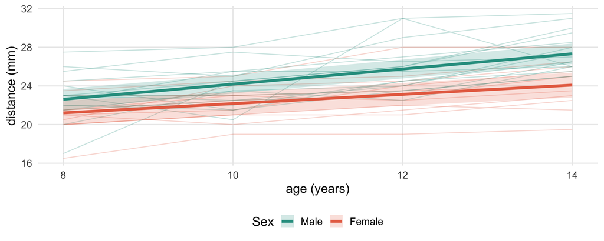

```r
pred <- ggpredict(o1, terms = c("age_c [0:6 by=0.5]", "Sex")) |>
  as_tibble() |>
  mutate(age = x + 8, Sex = group)

ggplot(pred, aes(age, predicted, color = Sex, fill = Sex)) +
  geom_line(data = ortho, aes(y = distance, group = Subject), alpha = .25, linewidth = .5) +
  geom_ribbon(aes(ymin = conf.low, ymax = conf.high), alpha = .2, color = NA) +
  geom_line(linewidth = 1.6) +
  scale_color_manual(values = pal_sex) + scale_fill_manual(values = pal_sex) +
  scale_x_continuous(breaks = c(8, 10, 12, 14)) +
  labs(x = "age (years)", y = "distance (mm)")
```

## 11b. The gap, age by age

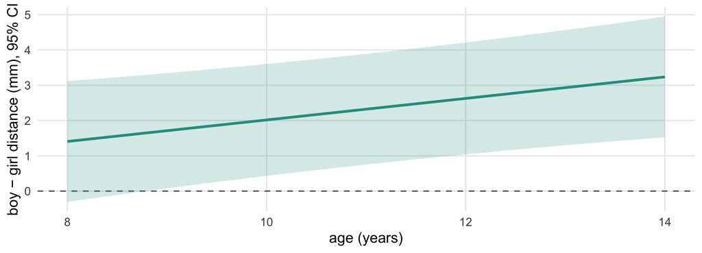

```r
gap <- emmeans(o1, ~ Sex | age_c, at = list(age_c = seq(0, 6, by = 0.5))) |>
  pairs() |>
  confint() |>
  as_tibble() |>
  mutate(age = age_c + 8)

ggplot(gap, aes(age, estimate)) +
  geom_hline(yintercept = 0, linetype = "dashed", color = muted) +
  geom_ribbon(aes(ymin = lower.CL, ymax = upper.CL), fill = fact, alpha = .2) +
  geom_line(color = fact, linewidth = 1.3) +
  scale_x_continuous(breaks = c(8, 10, 12, 14)) +
  labs(x = "age (years)", y = "boy − girl distance (mm), 95% CI")
```

The **effect of sex** as a function of age: ≈ 1.4 mm at 8 (band crosses 0), ≈ 3.2 mm at 14. The band leaves 0 at about age **9**. The slope of this line is `age_c:Sex`.

## 11c. Growth rates by sex

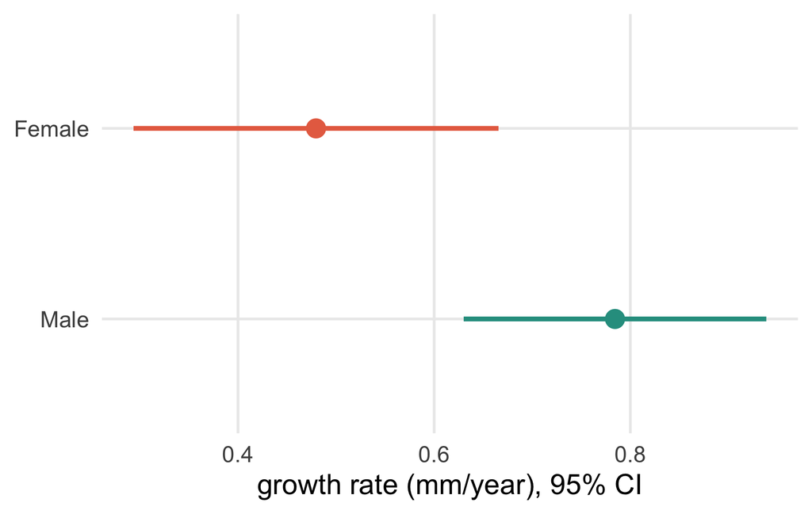

```r
as_tibble(tr1) |>
  ggplot(aes(age_c.trend, Sex, color = Sex)) +
  geom_pointrange(aes(xmin = lower.CL, xmax = upper.CL),
                  size = .8, linewidth = 1.2) +
  scale_color_manual(values = pal_sex, guide = "none") +
  labs(x = "growth rate (mm/year), 95% CI", y = NULL)
```

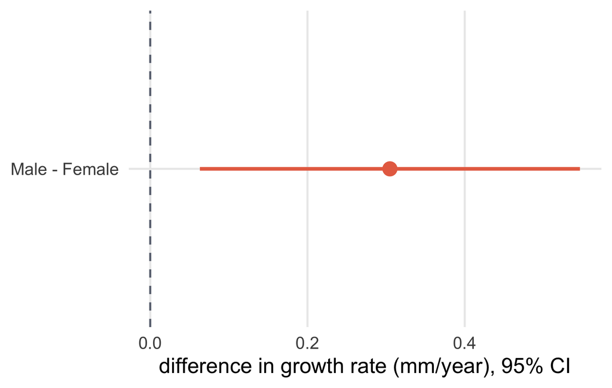

```r
confint(pairs(tr1)) |>
  as_tibble() |>
  ggplot(aes(estimate, contrast)) +
  geom_vline(xintercept = 0, linetype = "dashed", color = muted) +
  geom_pointrange(aes(xmin = lower.CL, xmax = upper.CL),
                  color = counter, size = .8, linewidth = 1.2) +
  labs(x = "difference in growth rate (mm/year), 95% CI", y = NULL)
```

Left: each sex’s rate. Right: the **effect** (boys − girls), its CI does not cross 0 → boys grow faster. The left CIs overlap a bit, yet the difference is clear: compare **differences**, not overlapping intervals.

## 11d. Each child vs its sex

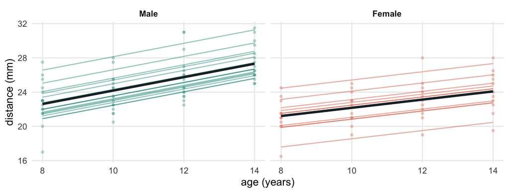

```r
ortho |>
  mutate(child_line = predict(o1),                 # Xβ + Zb_i (conditional)
         sex_line   = predict(o1, re.form = NA)) |> # Xβ       (marginal)
  ggplot(aes(age, color = Sex)) +
  geom_point(aes(y = distance), alpha = .3, size = 1.2) +
  geom_line(aes(y = child_line, group = Subject), alpha = .5) +
  geom_line(aes(y = sex_line), color = ink, linewidth = 1.6) +
  facet_wrap(~ Sex) +
  scale_color_manual(values = pal_sex, guide = "none") +
  scale_x_continuous(breaks = c(8, 10, 12, 14)) +
  labs(x = "age (years)", y = "distance (mm)")
```

Thin lines: each child’s fitted line, $X\hat\beta + Z\hat b_i$. Thick line: the sex’s line, $X\hat\beta$. With `o1` children’s lines are **parallel** to their sex’s line (own level, common rate): exactly what the random intercept assumes.

## 11e. Effects plot · each sex across ages

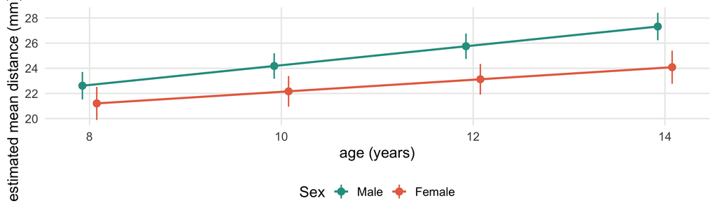

```r
emm_grid <- emmeans(o1, ~ Sex | age_c, at = list(age_c = c(0, 2, 4, 6))) |>
  as_tibble() |>
  mutate(age = age_c + 8)

ggplot(emm_grid, aes(age, emmean, color = Sex, group = Sex)) +
  geom_line(linewidth = 1, position = position_dodge(.3)) +
  geom_pointrange(aes(ymin = lower.CL, ymax = upper.CL), position = position_dodge(.3), size = .5) +
  scale_color_manual(values = pal_sex) +
  scale_x_continuous(breaks = c(8, 10, 12, 14)) +
  labs(x = "age (years)", y = "estimated mean distance (mm) ± 95% CI")
```

One line per sex: **how each sex grows with age**. The slope of each line is its growth rate (`emtrends`); lines that **diverge** = Sex × age interaction.

## 11f. Effects plot · each age across sexes

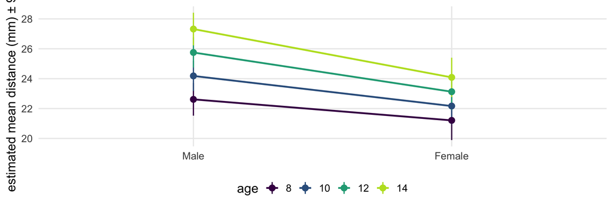

```r
ggplot(emm_grid, aes(Sex, emmean, color = factor(age), group = factor(age))) +
  geom_line(linewidth = 1) +
  geom_pointrange(aes(ymin = lower.CL, ymax = upper.CL), size = .5) +
  scale_color_viridis_d("age", end = .9) +
  labs(x = NULL, y = "estimated mean distance (mm) ± 95% CI")
```

Same estimates, axes swapped: one line per age, **how boys and girls compare at that age**. The slope of each line is the boy − girl gap: almost flat at 8, steeper at 14 → the sex effect **grows with age**. If there were no interaction, the lines would be **parallel** in both plots.

## Take-home

1. **Plot first**: different starts, parallel lines
2. **Random intercept** is enough (`o1`): a straight line is enough too.
3. Boys and girls start similar at 8 (gap ≈ 1.4 mm, n.s.) but **diverge**: ≈ 3.2 mm at 14.
4. Boys grow **≈ 0.3 mm/year faster**: the slope difference, the change in the gap and the interaction coefficient are the same number.
5. The covariance choice **does not change β̂** here, but it **changes SEs, df and p**.

## References

Potthoff, Richard F., and S. N. Roy. 1964. “A Generalized Multivariate Analysis of Variance Model Useful Especially for Growth Curve Problems.” *Biometrika* 51 (3/4): 313–26.